# Predicting the authorship of Beatles lyrics

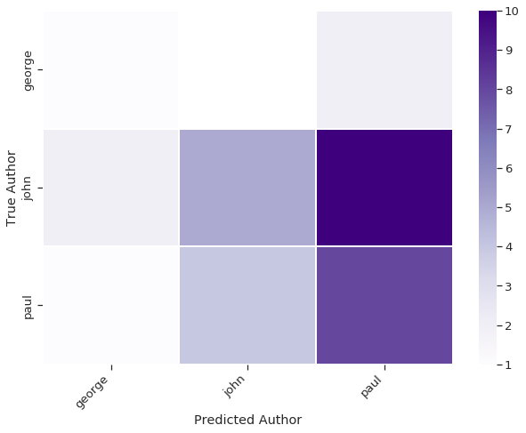

```python
# LR confusion matrix shows a lot of confusion b/w Paul and John, and George is not getting predicted at all

classifications_dict = defaultdict(int)
for _true_label, _predicted_label in zip(eval_labels, aug_lr_predictions):
    classifications_dict[(_true_label, _predicted_label)] += 1

dicts_to_plot = []
for (_true_author, _predicted_author), _count in classifications_dict.items():
    dicts_to_plot.append({'True Author': _true_author,
                        'Predicted Author': _predicted_author,
                        'Number of Classifications': _count})

df_to_plot = pd.DataFrame(dicts_to_plot)
df_wide = df_to_plot.pivot_table(index='True Author',
                                 columns='Predicted Author',
                                 values='Number of Classifications')

plt.figure(figsize=(9,7))
sns.set(style='ticks', font_scale=1.2)
sns.heatmap(df_wide, linewidths=1, cmap='Purples')
plt.xticks(rotation=45, ha='right')
plt.tight_layout()
plt.show()
```

Let's downsample the Paul datapoints, as he is over-represented by almost a factor of 3 compared to both George and John in the training data and the confusion matrix suggests the classifier is learning to mostly predict Paul.

```python
downsample_target = 125
RANDOM_SEED = 1969
np.random.seed(RANDOM_SEED)
paul_data = [item for item in aug_train_texts_with_labels if item[1]=='paul']
nonpaul_data = [item for item in aug_train_texts_with_labels if item[1]!='paul']
downsample_paul_ixs = set(np.random.choice(a=list(range(len(combined_texts_with_labels))),
                                           size=downsample_target, replace=False))
downsample_paul_data = [item for ix,item in enumerate(paul_data) if ix in downsample_paul_ixs]
print(f"Randomly chose {len(downsample_paul_data)} out of {len(paul_data)} \
datapoints total for downsampled train data.")

down_train_texts = [item[0] for item in downsample_paul_data + nonpaul_data]
down_train_labels = [item[1] for item in downsample_paul_data + nonpaul_data]
print(f"\nDistribution of downsampled train labels:", Counter(down_train_labels))
print(f"Distribution of eval labels:", Counter(eval_labels))
```

```
Randomly chose 125 out of 324 datapoints total for downsampled train data.

Distribution of downsampled train labels: Counter({'john': 126, 'paul': 125, 'george': 125})
Distribution of eval labels: Counter({'john': 17, 'paul': 13, 'george': 3})
```

```python
len(train_labels), len(down_train_labels)
```

```
(129, 376)
```

```python
# Logistic regression w/ different combinations of features

from sklearn.metrics import accuracy_score, precision_recall_fscore_support, classification_report
from sklearn.feature_extraction.text import CountVectorizer, TfidfVectorizer
from sklearn.linear_model import LogisticRegression
from sklearn.pipeline import FeatureUnion

ngram_vectorizer = CountVectorizer(analyzer='word', ngram_range=(1,4), min_df=5)
tfidf_vectorizer = TfidfVectorizer(min_df=5)
combined_features = FeatureUnion([("ngram", ngram_vectorizer),
                                  ("tfidf", tfidf_vectorizer),
                                  ("ttr", TTRExtractor()),
                                  ("first.sg", FirstSgPronounExtractor()),
                                  ("first.pl", FirstPlPronounExtractor()),
                                  ("second", SecondPronounExtractor()),
                                  ("she", ShePronounExtractor()),
                                  ("he", HePronounExtractor()),
                                  ("it", ItPronounExtractor()),
                                  ("they", TheyPronounExtractor()),
                                  ("valence", ValenceExtractor()),
                                  ("arousal", ArousalExtractor()),
                                  ("dominance", DominanceExtractor()),
                                  ("neg", NegationExtractor()),
                                  ("total_lines", TotalLinesExtractor()),
                                  ("total_words", TotalWordsExtractor()),
                                  ("total_lemmas", TotalLemmasExtractor()),
                                  ("mean_words", MeanWordsPerLineExtractor()),
                                  ("mean_chars", MeanCharsPerWordExtractor()),
                                 ])

# Use combined features to transform dataset:
print(f'Extracting features...')
X_train = combined_features.fit_transform(down_train_texts)
X_test = combined_features.transform(eval_texts)
print(f'\tObtained the following dimensions of train, test data:',X_train.shape, X_test.shape)

down_lr_model = LogisticRegression(max_iter=1000).fit(X_train, down_train_labels)
down_lr_predictions = down_lr_model.predict(X_test)

print(classification_report(eval_labels, down_lr_predictions))
```

```
Extracting features...
	Obtained the following dimensions of train, test data: (376, 2635) (33, 2635)
              precision    recall  f1-score   support

      george       0.33      0.67      0.44         3
        john       0.58      0.41      0.48        17
        paul       0.40      0.46      0.43        13

    accuracy                           0.45        33
   macro avg       0.44      0.51      0.45        33
weighted avg       0.49      0.45      0.46        33
```

```python
all_feats = [item[0] for item in combined_features.transformer_list]
best_lr_model = down_lr_model
best_acc = accuracy_score(eval_labels, down_lr_predictions)
for ablated_feat in all_feats:
    ablated_features = FeatureUnion([feat for feat in combined_features.transformer_list
                                     if feat[0] != ablated_feat])

    print(f'Extracting ablated features without {ablated_feat}...')
    X_train = ablated_features.fit_transform(down_train_texts)
    X_test = ablated_features.transform(eval_texts)
    print(f'\tObtained the following dimensions of train, test data:',X_train.shape, X_test.shape)

    model_ = LogisticRegression(max_iter=1000).fit(X_train, down_train_labels)
    predictions = model_.predict(X_test)

    print(classification_report(eval_labels, predictions))
    curr_acc = accuracy_score(eval_labels, predictions)
    if curr_acc > best_acc:
        best_lr_model = model_
        best_feat_set = ablated_features.transformer_list
        best_acc = curr_acc
```

```
Extracting ablated features without ngram...
	Obtained the following dimensions of train, test data: (376, 786) (33, 786)
              precision    recall  f1-score   support

      george       0.11      0.33      0.17         3
        john       0.64      0.41      0.50        17
        paul       0.46      0.46      0.46        13

    accuracy                           0.42        33
   macro avg       0.40      0.40      0.38        33
weighted avg       0.52      0.42      0.45        33

Extracting ablated features without tfidf...
	Obtained the following dimensions of train, test data: (376, 1866) (33, 1866)
              precision    recall  f1-score   support

      george       0.29      0.67      0.40         3
        john       0.50      0.35      0.41        17
        paul       0.36      0.38      0.37        13

    accuracy                           0.39        33
   macro avg       0.38      0.47      0.39        33
weighted avg       0.42      0.39      0.40        33

Extracting ablated features without ttr...
	Obtained the following dimensions of train, test data: (376, 2634) (33, 2634)
              precision    recall  f1-score   support

      george       0.29      0.67      0.40         3
        john       0.55      0.35      0.43        17
        paul       0.40      0.46      0.43        13

    accuracy                           0.42        33
   macro avg       0.41      0.49      0.42        33
weighted avg       0.46      0.42      0.43        33

Extracting ablated features without first.sg...
	Obtained the following dimensions of train, test data: (376, 2634) (33, 2634)
              precision    recall  f1-score   support

```

[output cut: 172 more lines]

```
    accuracy                           0.39        33
   macro avg       0.38      0.47      0.39        33
weighted avg       0.42      0.39      0.40        33

Extracting ablated features without mean_chars...
	Obtained the following dimensions of train, test data: (376, 2634) (33, 2634)
              precision    recall  f1-score   support

      george       0.14      0.33      0.20         3
        john       0.50      0.35      0.41        17
        paul       0.43      0.46      0.44        13

    accuracy                           0.39        33
   macro avg       0.36      0.38      0.35        33
weighted avg       0.44      0.39      0.41        33
```

```python
best_acc, [feat_name for feat_name, feat in best_feat_set]
```

```
(0.48484848484848486,
 ['ngram',
  'tfidf',
  'ttr',
  'first.sg',
  'first.pl',
  'second',
  'she',
  'he',
  'it',
  'they',
  'valence',
  'arousal',
  'dominance',
  'total_lines',
  'total_words',
  'total_lemmas',
  'mean_words',
  'mean_chars'])
```

```
Extracting best performing combination of features: ['ngram', 'tfidf', 'ttr', 'first.sg', 'first.pl', 'second', 'she', 'he', 'it', 'they', 'valence', 'arousal', 'dominance', 'total_lines', 'total_words', 'total_lemmas', 'mean_words', 'mean_chars']...
```

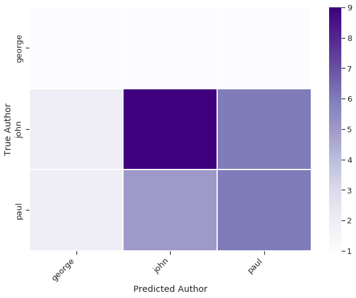

```python
# LR confusion matrix
print(f'Extracting best performing combination of features: {[feat[0] for feat in best_feat_set]}...')
X_test = FeatureUnion(best_feat_set).transform(eval_texts)
down_lr_predictions = best_lr_model.predict(X_test)

classifications_dict = defaultdict(int)
for _true_label, _predicted_label in zip(eval_labels, down_lr_predictions):
    classifications_dict[(_true_label, _predicted_label)] += 1

dicts_to_plot = []
for (_true_author, _predicted_author), _count in classifications_dict.items():
    dicts_to_plot.append({'True Author': _true_author,
                        'Predicted Author': _predicted_author,
                        'Number of Classifications': _count})

df_to_plot = pd.DataFrame(dicts_to_plot)
df_wide = df_to_plot.pivot_table(index='True Author',
                                 columns='Predicted Author',
                                 values='Number of Classifications')

plt.figure(figsize=(9,7))
sns.set(style='ticks', font_scale=1.2)
sns.heatmap(df_wide, linewidths=1, cmap='Purples')
plt.xticks(rotation=45, ha='right')
plt.tight_layout()
plt.show()
```

```python
ngram_feats = [item[0] for item in sorted(ngram_vectorizer.vocabulary_.items(),
                                          key=lambda x: x[1], reverse=False)]
tfidf_feats = [item[0] for item in sorted(tfidf_vectorizer.vocabulary_.items(),
                                          key=lambda x: x[1], reverse=False)]
feat_name2weight_per_beatle = {}
for label in [0, 1, 2]:
    feat_name2weight_per_beatle[{0:'george',1:'john',2:'paul'}[label]] = dict(zip(ngram_feats + tfidf_feats + \
                            [feat_name.upper() for feat_name, feat in best_feat_set][2:],
                             best_lr_model.coef_[label]))

top_feats_per_beatle = {}
for beatle in feat_name2weight_per_beatle:
    top_feats = sorted(feat_name2weight_per_beatle[beatle].items(), key=lambda x: x[1], reverse=True)[:20]
    top_feats_per_beatle[beatle] = [(item[0], round(item[1], 3)) for item in top_feats]
pd.DataFrame(top_feats_per_beatle)
```

|  | george | john | paul |
| --- | --- | --- | --- |
| 0 | (love you, 0.185) | (the sky, 0.219) | (the one, 0.285) |
| 1 | (THEY, 0.16) | (came to, 0.179) | (one you, 0.193) |
| 2 | (want to, 0.15) | (do you, 0.166) | (what you, 0.17) |
| 3 | (IT, 0.149) | (in your, 0.157) | (VALENCE, 0.158) |
| 4 | (your love, 0.142) | (in the sky, 0.156) | (SHE, 0.153) |
| 5 | (FIRST.SG, 0.142) | (my little, 0.146) | (you and, 0.152) |
| 6 | (with all, 0.141) | (me so, 0.143) | (the night, 0.142) |
| 7 | (out the, 0.131) | (your name, 0.142) | (me love, 0.142) |
| 8 | (without you, 0.127) | (at night, 0.125) | (with me, 0.128) |
| 9 | (you know, 0.122) | (time is, 0.123) | (it now, 0.127) |
| 10 | (you all, 0.118) | (our love, 0.115) | (no more, 0.119) |
| 11 | (you may, 0.117) | (MEAN_WORDS, 0.115) | (when you, 0.118) |
| 12 | (TOTAL_LEMMAS, 0.116) | (to me, 0.112) | (out of, 0.116) |
| 13 | (is to, 0.111) | (DOMINANCE, 0.109) | (in my, 0.113) |
| 14 | (don know, 0.111) | (and know, 0.108) | (you don, 0.113) |
| 15 | (it is, 0.109) | (the world, 0.105) | (for the, 0.111) |
| 16 | (got to, 0.107) | (it so, 0.104) | (it you, 0.106) |
| 17 | (do what, 0.106) | (so hard, 0.103) | (do it, 0.101) |
| 18 | (as it, 0.105) | (that you, 0.098) | (on your, 0.096) |
| 19 | (your feet, 0.1) | (let me, 0.098) | (the time, 0.092) |

```python
import torch
from transformers import DistilBertTokenizerFast, DistilBertForSequenceClassification
from transformers import Trainer, TrainingArguments
from sklearn.metrics import accuracy_score, classification_report

model_name = 'distilbert-base-cased'
device_name = 'cuda'
max_length = 512
cached_model_directory_name = 'distilbert-beatles-clf-solo-aug-downsample'

# Encode data
tokenizer = DistilBertTokenizerFast.from_pretrained(model_name)
unique_labels = set(label for label in train_labels)
label2id = {label: id for id, label in enumerate(unique_labels)}
id2label = {id: label for label, id in label2id.items()}

train_encodings = tokenizer(train_texts, truncation=True, padding=True, max_length=max_length)
test_encodings  = tokenizer(eval_texts, truncation=True, padding=True, max_length=max_length)

train_labels_encoded = [label2id[y] for y in train_labels]
test_labels_encoded  = [label2id[y] for y in eval_labels]

print(set(train_labels_encoded))
print(set(test_labels_encoded))

class MyDataset(torch.utils.data.Dataset):
    def __init__(self, encodings, labels):
        self.encodings = encodings
        self.labels = labels

    def __getitem__(self, idx):
        item = {key: torch.tensor(val[idx]) for key, val in self.encodings.items()}
        item['labels'] = torch.tensor(self.labels[idx])
        return item

    def __len__(self):
        return len(self.labels)

train_dataset = MyDataset(train_encodings, train_labels_encoded)
test_dataset = MyDataset(test_encodings, test_labels_encoded)

down_bert_model = DistilBertForSequenceClassification.from_pretrained(model_name, num_labels=len(id2label)).to(device_name)
training_args = TrainingArguments(
    num_train_epochs=3,              # total number of training epochs
    per_device_train_batch_size=16,  # batch size per device during training
    per_device_eval_batch_size=20,   # batch size for evaluation
    learning_rate=5e-5,              # initial learning rate for Adam optimizer
    warmup_steps=100,                # number of warmup steps for learning rate scheduler (set lower because of small dataset size)
    weight_decay=0.01,               # strength of weight decay
    output_dir='./results',          # output directory
    logging_dir='./logs',            # directory for storing logs
    logging_steps=100,               # number of steps to output logging (set lower because of small dataset size)
    evaluation_strategy='steps',     # evaluate during fine-tuning so that we can see progress
)

def compute_metrics(pred):
    labels = pred.label_ids
    preds = pred.predictions.argmax(-1)
    acc = accuracy_score(labels, preds)
    return {
      'accuracy': acc,
    }

trainer = Trainer(
    model=down_bert_model,               # the instantiated 🤗 Transformers model to be trained
    args=training_args,                  # training arguments, defined above
    train_dataset=train_dataset,         # training dataset
    eval_dataset=test_dataset,           # evaluation dataset (usually a validation set; here we just send our test set)
    compute_metrics=compute_metrics      # our custom evaluation function
)

trainer.train()

print(f"Saving model to: {cached_model_directory_name}")
trainer.save_model(cached_model_directory_name)

trainer.evaluate()

predicted_results = trainer.predict(test_dataset)
print(predicted_results.predictions.shape)

down_bert_predicted_labels = predicted_results.predictions.argmax(-1)           # Get the highest probability prediction
down_bert_predicted_labels = down_bert_predicted_labels.flatten().tolist()      # Flatten the predictions into a 1D list
down_bert_predicted_labels = [id2label[l] for l in down_bert_predicted_labels]  # Convert from integers back to strings for readability

print(classification_report(eval_labels, down_bert_predicted_labels))
```

[output not shown]

```
{0, 1, 2}
{0, 1, 2}
```

[output not shown]

[27/27 00:06, Epoch 3/3]

| Step | Training Loss | Validation Loss |
| --- | --- | --- |

```
Training completed. Do not forget to share your model on huggingface.co/models =)


Saving model checkpoint to distilbert-beatles-clf-solo-aug-downsample
Configuration saved in distilbert-beatles-clf-solo-aug-downsample/config.json
```

```
Saving model to: distilbert-beatles-clf-solo-aug-downsample
```

```
Model weights saved in distilbert-beatles-clf-solo-aug-downsample/pytorch_model.bin
***** Running Evaluation *****
  Num examples = 33
  Batch size = 20
```

[2/2 00:00]

```
***** Running Prediction *****
  Num examples = 33
  Batch size = 20
```

```
(33, 3)
              precision    recall  f1-score   support

      george       0.00      0.00      0.00         3
        john       0.67      0.12      0.20        17
        paul       0.40      0.92      0.56        13

    accuracy                           0.42        33
   macro avg       0.36      0.35      0.25        33
weighted avg       0.50      0.42      0.32        33
```

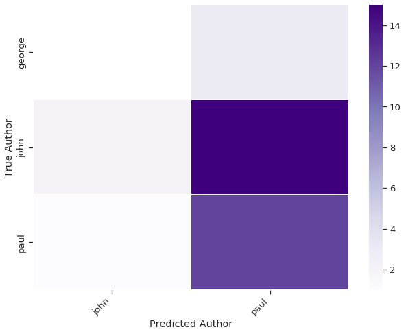

```python
classifications_dict = defaultdict(int)
for _true_label, _predicted_label in zip(eval_labels, down_bert_predicted_labels):
    classifications_dict[(_true_label, _predicted_label)] += 1

dicts_to_plot = []
for (_true_author, _predicted_author), _count in classifications_dict.items():
    dicts_to_plot.append({'True Author': _true_author,
                        'Predicted Author': _predicted_author,
                        'Number of Classifications': _count})

df_to_plot = pd.DataFrame(dicts_to_plot)
df_wide = df_to_plot.pivot_table(index='True Author',
                                 columns='Predicted Author',
                                 values='Number of Classifications')

plt.figure(figsize=(9,7))
sns.set(style='ticks', font_scale=1.2)
sns.heatmap(df_wide, linewidths=1, cmap='Purples')
plt.xticks(rotation=45, ha='right')
plt.tight_layout()
plt.show()
```

# Conclusion + other ideas

Overall, it appears that authorship attribution is a difficult task, with both feature-based and deep learning models performing at around the level of a moderate difficulty baseline. The difficulty stems in part from the sparse nature of song lyrics— even for musicians as prolific as The Beatles, each song provides only around 150 tokens after removing duplication in the form of choruses and repeated lines. (Fig. 5 shows the distribution of the unique number of token types (lemmas) and total number of tokens in all Beatles and solo career songs.)

```python
vocab_size_df = pd.DataFrame({'song': song_title2dedup_lyrics.keys(),
                              'vocab_size': [len(set([tok.lemma_ for tok in song_title2doc[song]]))
                                             for song in song_title2dedup_lyrics.keys()],
                              'num_tokens': [len([tok for tok in song_title2doc[song]])
                                             for song in song_title2dedup_lyrics.keys()]})
vocab_size_df.describe()
```

|  | vocab_size | num_tokens |
| --- | --- | --- |
| count | 623.000000 | 623.000000 |
| mean | 67.385233 | 152.611557 |
| std | 25.664028 | 63.356263 |
| min | 1.000000 | 1.000000 |
| 25% | 51.000000 | 114.000000 |
| 50% | 66.000000 | 147.000000 |
| 75% | 80.000000 | 185.000000 |
| max | 249.000000 | 651.000000 |

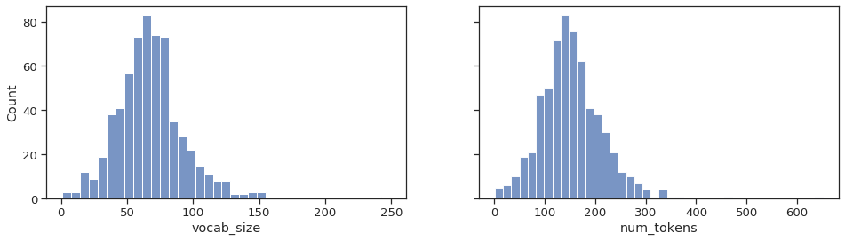

```python
fig, (ax1, ax2) = plt.subplots(1,2,figsize=(16,4),sharey=True)
sns.histplot(x='vocab_size',data=vocab_size_df,ax=ax1)
sns.histplot(x='num_tokens',data=vocab_size_df,ax=ax2)
```

# Footnotes

- 1. *A Savage Feast*, *Murder Riot*, *Severance*, *Blind Spot*, *My Favorite Thing Is Monsters*, just to name a few that come to mind.⤻
- 2. E.g., "In 1972 in an interview with Hit Parader magazine, John said about 'It's Only Love': 'That's the one song I really hate of mine. Terrible lyric.' Later, with David Sheff, he added: 'The lyrics were abysmal. I always hated that song.'".⤻
- 3. A hypothesis supported by [Cynthia Whissell's stylometric analysis of Beatles lyrics](https://link.springer.com/content/pdf/10.1007/BF00055109.pdf).⤻